# Day 2: Data Munging 1

Fay Walker

July 25, 2021 21:37

# 1 Review

- Assignment Operator
- Console/Environment/Script
- Comment your code and read your error messages

# 2 The tidyverse package

- Collection of packages using same syntax and grammar
- Works with “tidy” data
- Uses tibbles (https://r4ds.had.co.nz/tibbles.html)
- %>%

# 3 Primary functions

- `select()`
- `rename()`
- `filter()`
- `arrange()`
- `mutate()`
- `group_by()`
- `summarize()`

All of these functions have the same structure.

1. The first argument is the dataframe
2. The subsequent arguments describe what to do with the data frame, using the variable names (without quotes because you’re already refering to that df)
3. Separate functions by %>%
4. The result is a new data frame.

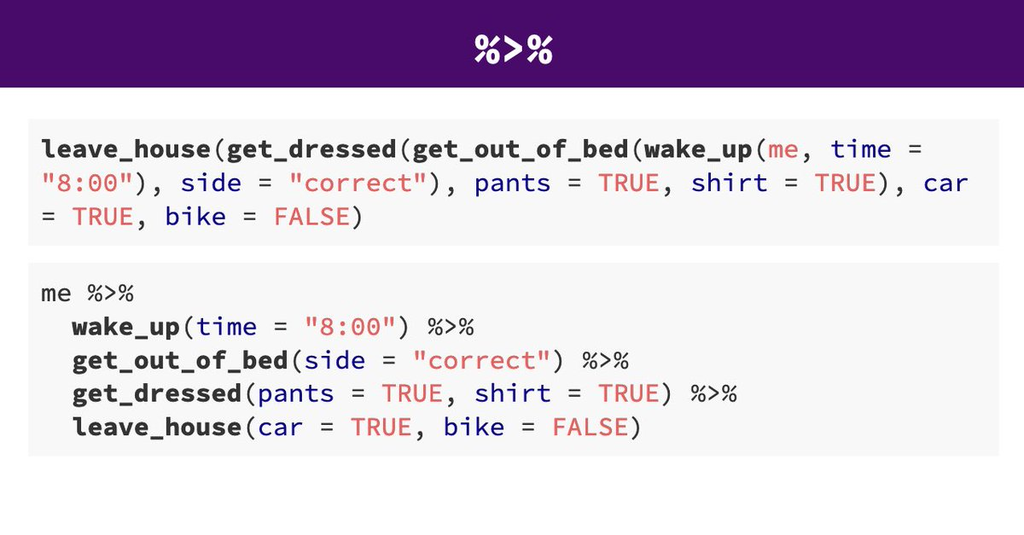

- If you have hit an error, trying running it line by line (function by function)

Source: [R for data science](https://r4ds.had.co.nz/transform.html)

# 4 Exercise 0: Creating a Project and Loading Packages

If you are using a different computer or didn’t attend sessions 0 or 1, follow steps 1 and 2. If not- skip to step 3.

**Step 1:** Open RStudio. File > New Project > New Directory > Select the location where you would like to create a new folder that houses your R Project. Call it `urbn101`.

**Step 2:** Open an `.R` script with the button in the top left (sheet with a plus sign icon). Save the script as `02_data-munging1.R`.

**Step 3:** If you have not previously installed `library(tidyverse)`: submit `install.packages("tidyverse")` to the Console (type and hit enter)

**Step 4:** Write `library(tidyverse)` at the top of `02_data-munging1.R`. With the cursor on the line of text, click Control-Enter.

# 5 Exercise 1: Tidyverse Function Overview

**Step 1:** Assign the `storms` dataset to be called storms. Submit `View(storms)` in the console.

You can also deselect specific columns in your data by using the `-` operator

**Select**

`select()` is used when you want to limit the number of **columns** in your dataframe. The arguments after the dataframe should be names of columns, without quotes. For example:

```
dataset %>%
  select(col1, col2)
```

**Step 2:** Create a new dataset with all the variables except for `ts_diameter` and `hu_diameter`, by using `select` and `-`.

**Step 3:** Create a new dataset that only category 5 storms using `filter()`.

**Filter**

`filter()` is used when you want to filter to specific rows in your dataframe, based on certain conditions. Filter works with the following comparison operators:

- `<`, `>`, `<=`, `>=`
- `==`, `!=`

You can also chain together multiple condtions with `&` (and) or `|` (or). The arguments after the dataframe should be conditions you want to filter your dataset on. For example

```
dataset %>%
filter(col1>0)
```

**Step 4:** Chain all of these commands together with the `%>%` operator. Then rename the column `pressure` to `air_pressure`.

**Rename**

The syntax for rename is:

```
dataset %>%
  rename(new_name = current_name)
```

This same syntax can be used inside `select()`, and you can rename and select variables simultanously.

**Step 5:** `wind` is measured in knots. Convert `wind` into miles per hour. Each knot is equal to 1.15078 miles per hour.

**Mutate**

`mutate()` can make new variables and edit existing variables. New variables are always added to the end of the dataframe. You can use arithmetic arguments, such as `+`, `-`, `*`, `/`, and `^`. The syntax for mutate is:

```
dataset %>%
  mutate(new_column = 100 * other_column)
```

**Step 6:** Make a dataset with storms that occured in the summer (June, July, August).

**The `%in%` operator**

The `%in%` operator is useful for filtering based on more than one option within one variable.

```
filter(dataset, var1 == "a" | var1 == "b" | var1 == "c")
```

is equivalent to

```
dataset %>%
filter(var1 %in% c("a", "b", "c"))
```

# 6 Exercise 2: If/Then and Summarizing

**Step 1:** Use the `txhousing` dataset. Assign the dataset to an object in your global environment named `tx_housing`.

**Step 2:** Compute a new variable, `average_price` by dividing `volume` by `sales`.

**Step 3:** Use `if_else()` to create a variable called `flag` that is 1 if the average sales price is larger than the median sales price.

**If/then logic**

`if_else()` is an important tool in combination with `mutate()`. It employs if-then logic: the first argument is a binary statement. The second statement says what to do if the first argument is evaluated to `TRUE`- the third is what to do if it is `FALSE` This is particularly useful for creating dummy or indicator variables. When you have more than two possible outcomes, it is more efficient to use `case_when()`.

**Step 3a:** Type `?case_when` into the console.

**Step 4:** Type the following code into your script.

```
tx_housing %>%
  group_by(year) %>%
  summarize(yearly_sales = sum(sales))
```

**Group By**

`group_by` groups your dataframe into discrete categories. It can be very powerful when used with `summarize`.

**Summarize**

[output not shown]

or

```
dataset %>%
  group_by(col1) %>%
  summarize(count=n())
```

**Step 5:** Add the argument `na.rm = TRUE` to the `sum()` function and rerun the code. Add a comment to explain the code.

**Step 6:** Sort the results of the previous code in order from most to least sales by adding `%>% arrange(desc(yearly_sales))` to the end of the code.

**Step 7a:** Which city had the most home sales in January 2008? (Hint: use `filter()` and `arrange()`).

**Step 7b:** Which city had the least home sales in 2006? (Hint: group by the city and the year- then use `summarize()`).

**BONUS:** Plot the number of annual home sales over time!

# 7 Exercise 3: Put it all together

**Step 1:** Use the `starwars` dataframe. Type `count(starwars, homeworld)` into your script.

**Step 2:** Filter out any characters that have a missing `homeworld`.

**Step 3:** Find the average and median height and mass for humans vs. droids. (Hint: use `group_by()` and `summarize()`). Make sure that you are correcting for observations with missing values!

**Step 4:** Make a dummy variable called `droid` that is `1` for droids and `0` for humans. Make a variable called `tall` that is `1` if the characters are more than 200 cm tall. How many tall humans are there?

**Step 5:** What is the most common skin color for droids?

# 8 Resources

- [R for Data Science: data transformation](https://r4ds.had.co.nz/transform.html)
- [Data wrangling cheat sheet](https://www.rstudio.com/wp-content/uploads/2015/02/data-wrangling-cheatsheet.pdf)